# Práctica 3

Modelamiento estadístico

2025-03-17

# Desviación estándar

Es un estadístico fundamental para medir la dispersión de los datos, y en la regresión tiene un papel importante al momento de calcular la varianza asintótica de los estimadores y sus correspondientes errores estándares.

El programa STATA calcula la desviación estándar de los errores de la siguiente manera:

$$\hat\sigma=\sqrt{\frac{1}{N-K}\sum_{i=1}^N(\hat e_i)}$$

donde $\hat e_i =y_i-x_i'\hat \beta$. Este es un estimador consistente de la desviación estándar.

$$\hat\sigma\rightarrow^p \sigma$$
Para visualizar esta propiedad, vamos a crear un gran número de muestras para una variable aleatoria $y_N$, donde $y\sim N(10,4)$ y estimaremos $\sigma_y$ utilizando $\hat\sigma_y$ haciendo crecer $N$.

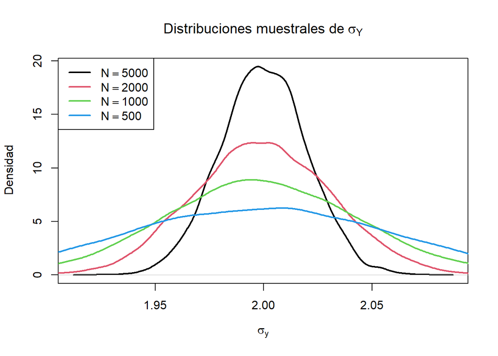

```r
# vector de tamaños de muestra
N <- c(5000, 2000, 1000, 500)

# graficar las desviaciones usando sd (standar deviations) para los diferentes tamaños de muestra
sq_y <- replicate(n = 10000, expr = sd(rnorm(N[1], 10, 2)))
plot(density(sq_y),
     main = expression("Distribuciones muestrales de" ~ sigma[Y]),
     xlab = expression(sigma[y]),
     ylab = expression("Densidad"),
     lwd = 2)

for (i in 2:length(N)) {
  sq_y <- replicate(n = 10000, expr = sd(rnorm(N[i], 10, 2)))
  lines(density(sq_y),
        col = i,
        lwd = 2)
}

# añadimos leyenda
legend("topleft",
       legend = c(expression(N == 5000),
                  expression(N == 2000),
                  expression(N == 1000),
                  expression(N == 500)),
       col = 1:5,
       lwd = 2)
```

La distribución de $\hat\sigma$ se acerca al verdadero valor $\sigma=2$ cuando $N$ incrementa.

# Ejercicio Práctico

*Growth* contiene data de crecimiento promedio para 65 países en el periodo 1960-1995, adicionalmente tiene variables potencialmente relacionadas con el crecimiento. Este data set proviene del artículo “Finance and the Sources of Growth” (JFE,2000) de Levine, Beck y Loayza.

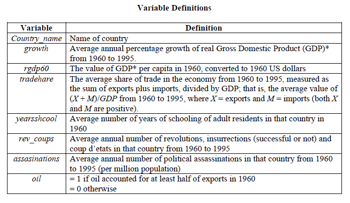

1. Visualice los datos y variables
2. Si estamos interesados en la relación entre `tradeshare` y `crecimiento`, realice un gráfico que ayude a visualizar dicha relación.
3. Calcule e interprete el coeficiente correlación de pearson :

$$\rho_{xy}=\frac{Cov(xy)}{\sigma_x \sigma_y}$$
Donde $\sigma_x,\sigma_y$ son las deasviaciones estándar de cada variable.

4. Realice una estimación lineal del modelo:

$$growth_i=\beta_0+\beta_1 tradeshare + u_i$$

5. Con la información previa, calcule manualmente el t estadístico, el valor crítico y el p-valor para un nivel de significancia de $\alpha=0.05$.
6. Calcule e interprete el intervalo de confianza para el $\beta$ estimado.

Un intervalo de confianza es un rango de valores, derivado de una muestra de datos, que con cierta probabilidad (nivel de confianza) contiene el verdadero valor de un parámetro poblacional.

En MCO ayuda a medir la incertidumbre alrededor de los coeficientes estimados.

Para un coeficiente estimado $\hat\beta$, su *intervalo de confianza* al $(1-\alpha)\%$ se calcula como:

$$IC = \beta\pm c_\alpha*SE$$

7. Realice un gráfico ajustando una línea de regresión a los datos